# Ford GoBike Data Exploration

## by Ayush Mathur

## Introduction

> A bike-share system is a service in which bicycles are made available for shared use to individuals on a short term basis for a price or free. Many bike share systems allow people to borrow a bike from a "dock" and return it at another dock belonging to the same system. Ford GoBike is a public bicycle sharing system in San Francisco Bay Area, California. currently has over 2,600 bicycles in 262 stations across San Francisco, East Bay and San Jose. As of January 2018, the system had seen nearly 500,000 rides since the launch in 2017 and had about 10,000 annual subscribers.

## Preliminary Wrangling

In this project, we are analyzing data from 2017 to July 2019.

## Ford GoBike Rides per month

- Frequency of rides is highest during the month of July. Followed by months of June, April, March and May.
- Summers have the highest demand of Ford GoBike. Winters have the least number of rides. December and November having the least couny of rides.

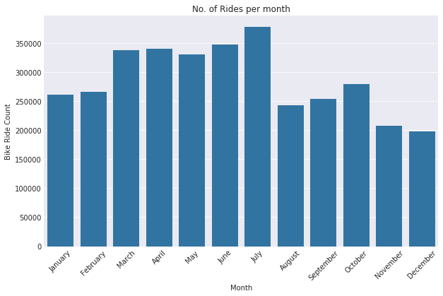

```python
base_color = sns.color_palette()[0]
plt.figure(figsize=(10,6))
g = sns.countplot(data=df_bike_master, x='start_month', color=base_color)
plt.xticks(rotation = 45)
plt.xlabel('Month')
plt.ylabel('Bike Ride Count')
plt.title('No. of Rides per month');
```

## Bike Rides over a week

- Apparantly, Weekends have the least number of rides. Tuesday, Wednessday and Thursday having highest count.
- We have a moderate count for Monday and Friday. I expected highest frequency on weekends.

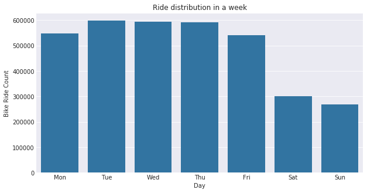

```python
plt.figure(figsize=(10,5))
g = sns.countplot(data=df_bike_master, x='start_weekday', color=base_color)
plt.xlabel('Day')
plt.ylabel('Bike Ride Count')
plt.title('Ride distribution in a week');
```

## Bike Rides hourly distribution

- We have the peak hours during 8 to 9 in morning and 16 to 18 in the evening.
- And a moderate use during the day.
- the bikes are used during the office commute hours.

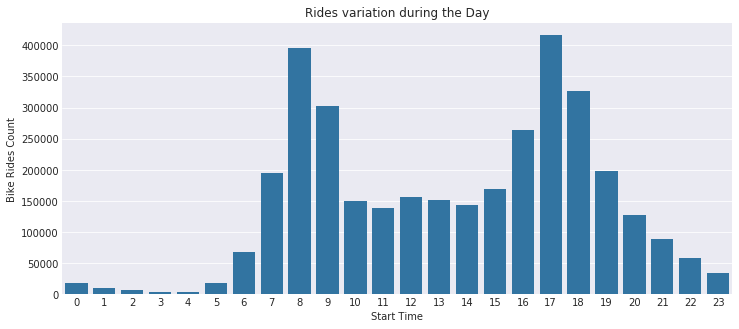

```python
plt.figure(figsize=(12,5))
g = sns.countplot(data=df_bike_master, x='start_hour', color=base_color)
plt.title('Rides variation during the Day')
plt.xlabel('Start Time')
plt.ylabel('Bike Rides Count');
```

## Ride variation per trip duration

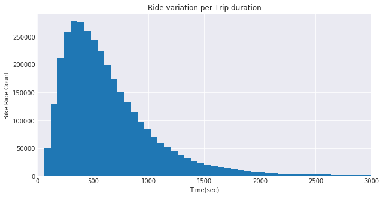

```python
plt.figure(figsize=(10,5))
bins = np.arange(df_bike_master['duration_sec'].min(),df_bike_master['duration_sec'].max()+60, 60)
plt.hist(df_bike_master['duration_sec'], bins=bins)
plt.xlim(0,3000)
plt.xlabel('Time(sec)')
plt.ylabel('Bike Ride Count')
plt.title('Ride variation per Trip duration');
```

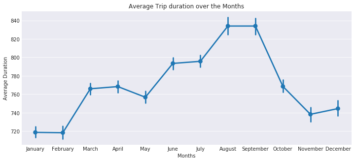

```python
fig,ax = plt.subplots(figsize = (12,5))
sns.pointplot(ax=ax, data=df_bike_master, x='start_month', y='duration_sec')
ax.set_title('Average Trip duration over the Months')
ax.set(xlabel='Months', ylabel='Average Duration');
```

## Customer v/s Subscriber trend over the Year

- Subscribers have the similar trend as the overall trend. It is probably because the dataset is subscriber heavy.
- Subscribers and customers both have the more number of rides in summer than winter.
- Subscribers have peak around July whereas customers have peak in April.

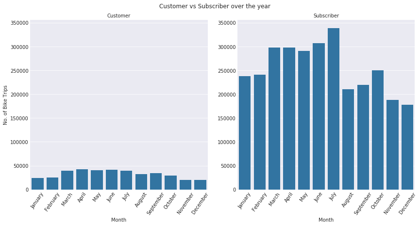

```python
g = sns.FacetGrid(data=df_bike_master, col='user_type', size=6)
g.map(sns.countplot, 'start_month')
g.set_xticklabels(rotation=55)
plt.subplots_adjust(top=0.9)
g.fig.suptitle('Customer vs Subscriber over the year')
g.set_axis_labels("Month", "No. of Bike Trips")
g.set_titles('{col_name}');
```

## Hour-Week-Monthly Distribution

- 8 and 17 are the busiest hours of the day throughout the year.
- Weekends have the minimum demand.
- Overall peak hours of the day are 7 to 9 and 16 to 19.
- Months from March to July receive the most demand.
- There is some amount of demand even through the night.
- Monday and Tuesday in July will have the highest demand.
- Tuesday to Thursday from April to July have the overall highest demand.
- Weekends have the least demand as well as the months of November and December.
- Rest of the time we have moderate demand.

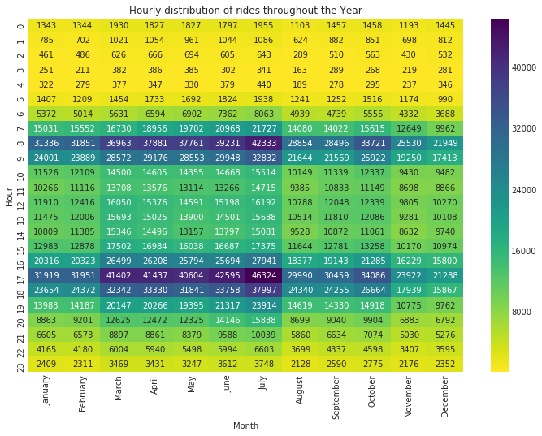

```python
df = df_bike_master.groupby(['start_month', 'start_hour']).size()
df = df.reset_index(name='count')
df = df.pivot(index='start_hour', columns='start_month', values='count')
fig,ax = plt.subplots(figsize=(12,8))
sns.heatmap(df,annot=True, fmt='d', cmap='viridis_r', ax=ax)
ax.set_title('Hourly distribution of rides throughout the Year')
ax.set(xlabel='Month', ylabel='Hour');
```

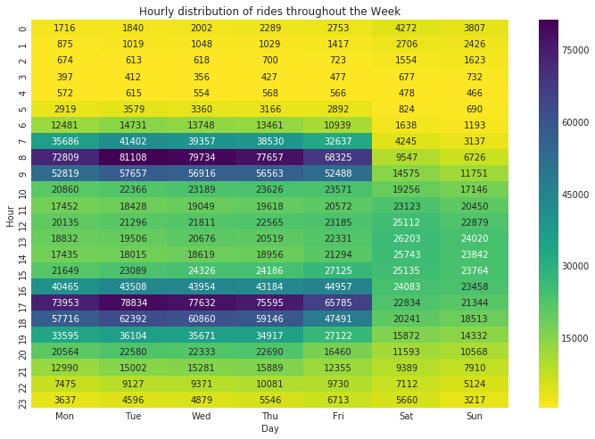

```python
df = df_bike_master.groupby(['start_weekday', 'start_hour']).size()
df = df.reset_index(name='count')
df = df.pivot(index='start_hour', columns='start_weekday', values='count')
fig,ax = plt.subplots(figsize=(12,8))
sns.heatmap(df,annot=True, fmt='d', cmap='viridis_r', ax=ax)
ax.set_title('Hourly distribution of rides throughout the Week')
ax.set(xlabel='Day', ylabel='Hour');
```

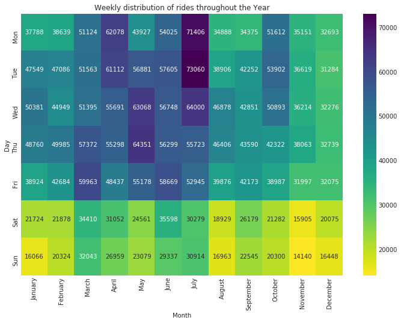

```python
df = df_bike_master.groupby(['start_month', 'start_weekday']).size()
df = df.reset_index(name='count')
df = df.pivot(index='start_weekday', columns='start_month', values='count')
fig,ax = plt.subplots(figsize=(12,8))
sns.heatmap(df,annot=True, fmt='d', cmap='viridis_r', ax=ax)
ax.set_title('Weekly distribution of rides throughout the Year')
ax.set(xlabel='Month', ylabel='Day');
```

## Distance over the year by Age groups

- Mostly all the age groups show similar trends except for the teenagers(age: 10-20)
- All groups have peaks in March whereas teenagers have peak during June-July when others have the least mean distance.
- Users within the age group 30 to 40 have the highest mean distance.

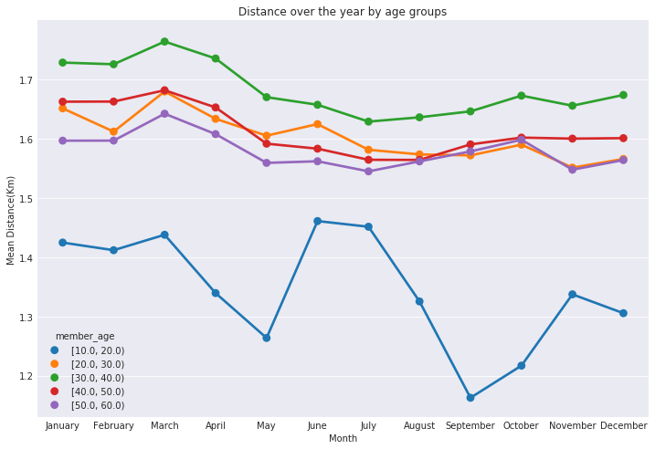

```python
fig,ax = plt.subplots(figsize=(12,8))
df = df_bike_master.groupby(['start_month',age_bin]).agg({'distance':'mean'}).reset_index()
sns.pointplot(data=df, x='start_month', y='distance', hue='member_age', ax=ax)
ax.set_title('Distance over the year by age groups')
ax.set(xlabel='Month', ylabel='Mean Distance(Km)');
```

## Duration over the year by Age groups

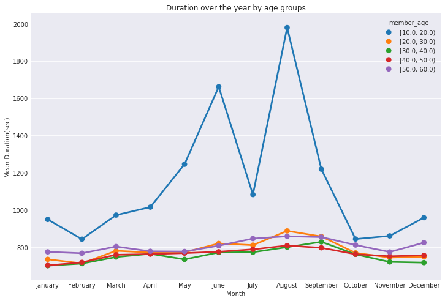

```python
fig,ax = plt.subplots(figsize=(12,8))
df = df_bike_master.groupby(['start_month',age_bin]).agg({'duration_sec':'mean'}).reset_index()
sns.pointplot(data=df, x='start_month', y='duration_sec', hue='member_age', ax=ax)
ax.set_title('Duration over the year by age groups')
ax.set(xlabel='Month', ylabel='Mean Duration(sec)');
```